# primaryModel

eb.navarro

June 27, 2016

# PRIMARY MODEL

## Introduction

This markdown notebook has been created to build a primary model created with decision tree and a random forest with cross validation. It is quite similar as done in Datacamp, but with slight exploratory additions.

### Loading the data

First of all, we load the data with my own function “loadCleanData”.

The object “fullData” includes train and test sets distinguished by the column named “SampleOrigin”.

*NOTE:* This process and others have been included in different functions for future usage.

```r
loadCleanData <- function(){

  # READ DATA
  trainPath = "data/train.csv"
  testPath = "data/test.csv"
  train <- read.csv(trainPath, header = TRUE, sep = ",", stringsAsFactors = FALSE)
  test <- read.csv(testPath, header = TRUE, sep = ",", stringsAsFactors = FALSE)

  # Joining datasets to analyse better the whole data
  train$SampleOrigin <- 'TRAIN'
  test$SampleOrigin <- 'TEST'
  test$Survived <- NA

  fullData <- rbind(train, test)
  # anyDuplicated(fullData$PassengerId) # As it is 0, we can consider this field as

  # Prepare data by type
  fullData$SampleOrigin = factor(fullData$SampleOrigin)
  fullData$Survived <- factor(fullData$Survived)
  fullData$Pclass <- factor(fullData$Pclass)
  fullData$Sex <- factor(fullData$Sex)
  fullData$Embarked <- factor(fullData$Embarked)

  return(fullData)
}

fullData <- loadCleanData()
str(fullData)
```

```
## 'data.frame':    1309 obs. of  13 variables:
##  $ PassengerId : int  1 2 3 4 5 6 7 8 9 10 ...
##  $ Survived    : Factor w/ 2 levels "0","1": 1 2 2 2 1 1 1 1 2 2 ...
##  $ Pclass      : Factor w/ 3 levels "1","2","3": 3 1 3 1 3 3 1 3 3 2 ...
##  $ Name        : chr  "Braund, Mr. Owen Harris" "Cumings, Mrs. John Bradley (Florence Briggs Thayer)" "Heikkinen, Miss. Laina" "Futrelle, Mrs. Jacques Heath (Lily May Peel)" ...
##  $ Sex         : Factor w/ 2 levels "female","male": 2 1 1 1 2 2 2 2 1 1 ...
##  $ Age         : num  22 38 26 35 35 NA 54 2 27 14 ...
##  $ SibSp       : int  1 1 0 1 0 0 0 3 0 1 ...
##  $ Parch       : int  0 0 0 0 0 0 0 1 2 0 ...
##  $ Ticket      : chr  "A/5 21171" "PC 17599" "STON/O2. 3101282" "113803" ...
##  $ Fare        : num  7.25 71.28 7.92 53.1 8.05 ...
##  $ Cabin       : chr  "" "C85" "" "C123" ...
##  $ Embarked    : Factor w/ 4 levels "","C","Q","S": 4 2 4 4 4 3 4 4 4 2 ...
##  $ SampleOrigin: Factor w/ 2 levels "TEST","TRAIN": 2 2 2 2 2 2 2 2 2 2 ...
```

```r
summary(fullData)
```

```
##   PassengerId   Survived   Pclass      Name               Sex
##  Min.   :   1   0   :549   1:323   Length:1309        female:466
##  1st Qu.: 328   1   :342   2:277   Class :character   male  :843
##  Median : 655   NA's:418   3:709   Mode  :character
##  Mean   : 655
##  3rd Qu.: 982
##  Max.   :1309
##
##       Age            SibSp            Parch          Ticket
##  Min.   : 0.17   Min.   :0.0000   Min.   :0.000   Length:1309
##  1st Qu.:21.00   1st Qu.:0.0000   1st Qu.:0.000   Class :character
##  Median :28.00   Median :0.0000   Median :0.000   Mode  :character
##  Mean   :29.88   Mean   :0.4989   Mean   :0.385
##  3rd Qu.:39.00   3rd Qu.:1.0000   3rd Qu.:0.000
##  Max.   :80.00   Max.   :8.0000   Max.   :9.000
##  NA's   :263
##       Fare            Cabin           Embarked SampleOrigin
##  Min.   :  0.000   Length:1309         :  2    TEST :418
##  1st Qu.:  7.896   Class :character   C:270    TRAIN:891
##  Median : 14.454   Mode  :character   Q:123
##  Mean   : 33.295                      S:914
##  3rd Qu.: 31.275
##  Max.   :512.329
##  NA's   :1
```

As we could see in these descriptive analyses, there are observations with unknown values for several variables. First of all we should to solve it.

## Handling with missings

The first missing to be fullfiled is one corresponding to “Fare” variable. As it is really simple we just set its value to the mean of the all other values of this variable. Additionally, the variable “Embarked” contain 2 observations with unknown values, but we can see the “Fare” of these observations. As the value is really high (80 pounds per ticket), the embarkation with this fare is likely to be “C”, as others (“Q” and “S”) are lower.

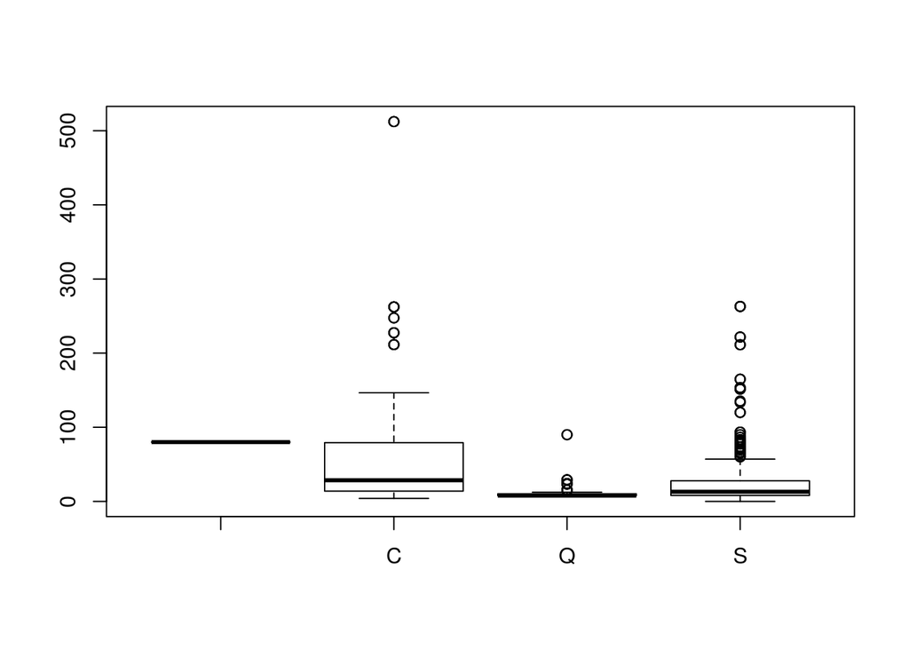

```r
missings.fare <- which(is.na(fullData$Fare)) # returns 1044
fullData[missings.fare,]$Fare <- mean(fullData$Fare[!is.na(fullData$Fare)])

missings.embarked <- which(fullData$Embarked == "")
missings.embarked.boxplot <- boxplot(Fare~Embarked, data=fullData)
```

```r
# Five numbers of "Fare" for each "Embarked" factor.
missings.embarked.boxplot$stats
```

```
##      [,1]      [,2]    [,3]  [,4]
## [1,]   80   4.01250  6.7500  0.00
## [2,]   80  13.85830  7.7500  8.05
## [3,]   80  28.51875  7.7500 13.00
## [4,]   80  79.20000 10.1979 27.75
## [5,]   80 146.52080 12.3500 57.00
```

```r
fullData[which(fullData$Embarked==""),]$Embarked <- 'C'
fullData$Embarked <- factor(fullData$Embarked)
levels(fullData$Embarked)
```

```
## [1] "C" "Q" "S"
```

To fix the “Age” missings is a bit triky. It does not seem to exist any variable which can be useful to impute this data missing, so we will do it using a prediction with regression tree.

```r
age_imputation <- function() {
  # Computes the age imputation for missing values.
  require(rpart)
  fit <- rpart(formula = Age ~ Pclass + Sex + SibSp + Parch + Fare, data = fullData[!is.na(fullData$Age),])

  prediction.age <- predict(fit, fullData[is.na(fullData$Age),])
  data.frame.age.actual <- data.frame(PassengerId = fullData$PassengerId, Age = fullData$Age)
  data.frame.age.predicted <- data.frame(PassengerId = fullData[is.na(fullData$Age),]$PassengerId, Age = round(prediction.age))

  data.frame.age <- merge(data.frame.age.actual, data.frame.age.predicted, by = c("PassengerId", "Age"), all = TRUE)

  return(data.frame.age[!is.na(data.frame.age$Age),])
}
```

Once created the “age_imputation” function, we use it to include the imputations to the fullData variable.

```r
actual.predicted.age <- age_imputation()
missing.age.PassIds = fullData[which(is.na(fullData$Age)),]$PassengerId
fullData[fullData$PassengerId %in% missing.age.PassIds,]$Age <- actual.predicted.age[actual.predicted.age$PassengerId %in% missing.age.PassIds,]$Age
```

# Primary Model

Once we have all the missings imputed, the next step is to create a simple model and try to do a cross validation with known data (‘Survived’ attribute).

## Include additional variables

Increasing the dataset with simple modifications from the original data: 1) *Family_size*: grouping (adding) the number of relatives related with each sample. 2) *Title*: extraction of the personal title usually included with the its name.

First the creation of specific function to create these new variables:

```r
family_total_count <- function() {
  # Family total count
  data.frame.family_size <- data.frame(PassengerId = fullData$PassengerId, Family_size = fullData$SibSp + fullData$Parch + 1)
  return(data.frame.family_size)
}
```

```r
title_extraction <- function() {
  # Title extraction
  # Grab title from passenger names. Inspired from Megan L. Risdal idea.
  fullData$Title <- as.factor(gsub('(.*, )|(\\..*)', '', fullData$Name))
  mainTitleRows <- which((fullData$Title %in% c('Mr', 'Miss', 'Master', 'Mrs')) == TRUE)
  otherTitleRows <- which((fullData$Title %in% c('Mr', 'Miss', 'Master', 'Mrs')) == FALSE)
  levels(fullData$Title) <- c(levels(fullData$Title), "Other")
  fullData[otherTitleRows,]$Title <- 'Other'
  fullData$Title <- droplevels(fullData$Title)
  data.frame.title <- data.frame(PassengerId = fullData$PassengerId, Title = fullData$Title)

  return(data.frame.title)
}
```

Merging the new variables by the “PassengerId”.

```r
actual.predicted.family_size <- family_total_count()
actual.predicted.title <- title_extraction()
fullData <- merge(fullData, actual.predicted.title, by = "PassengerId")
fullData <- merge(fullData, actual.predicted.family_size, by = "PassengerId")
```

## Cross validation settings

Separation of known “survived” attribute in the training dataset to create 70% as “train” set and 30% as “cross” validation subset. The “test” set is the already unknown “survived” values.

```r
require(caret)
train <- fullData[fullData$SampleOrigin=='TRAIN',]
sampleNumbers = dim(train)
folds = createDataPartition(train$PassengerId, p=0.7, list = FALSE, times = 1)

trainSamples <- train[folds,]
crossSamples <- train[-folds,]
test <- fullData[fullData$SampleOrigin=='TEST',]
```

## Model creation

First model with regresion tree. Once the main variables are detected, we prune the trained tree to generalize predictions.

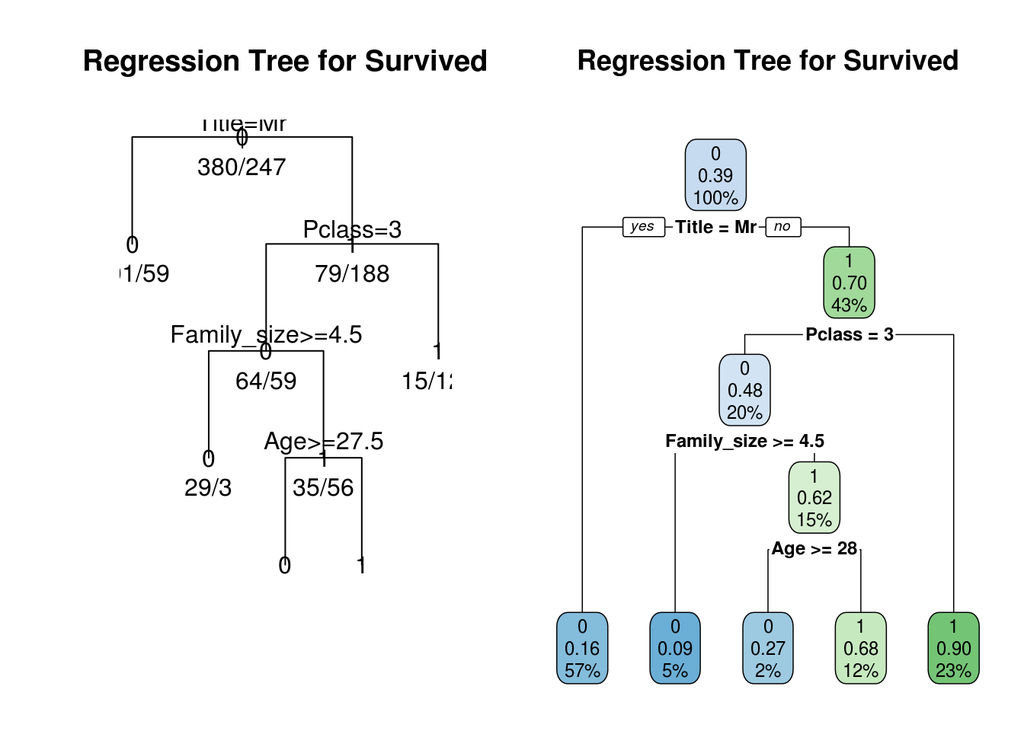

```r
require(rpart)
require(rpart.plot)
fit <- rpart(Survived ~ Pclass + Sex + Age + Fare + SibSp + Parch + Embarked  + Title + Family_size, data = trainSamples, method = "class")

# Some charts (tree chart and CP's)
par(mfrow=c(1, 2))
plot(fit, uniform=TRUE,main="Regression Tree for Survived")
text(fit, use.n=TRUE, all=TRUE, pretty = 0)

rpart.plot(fit, uniform=TRUE,main="Regression Tree for Survived")
```

```r
printcp(fit) # display the results
```

```
##
## Classification tree:
## rpart(formula = Survived ~ Pclass + Sex + Age + Fare + SibSp +
##     Parch + Embarked + Title + Family_size, data = trainSamples,
##     method = "class")
##
## Variables actually used in tree construction:
## [1] Age         Family_size Pclass      Title
##
## Root node error: 247/627 = 0.39394
##
## n= 627
##
##         CP nsplit rel error  xerror     xstd
## 1 0.441296      0   1.00000 1.00000 0.049535
## 2 0.052632      1   0.55870 0.55870 0.042001
## 3 0.028340      3   0.45344 0.46964 0.039365
## 4 0.010000      4   0.42510 0.46964 0.039365
```

```r
plotcp(fit) # visualize cross-validation results
fit$variable.importance
```

```
##       Title         Sex Family_size        Fare         Age       Parch
##   94.712557   77.284235   44.068583   40.234871   36.679929   34.055988
##      Pclass       SibSp    Embarked
##   22.977562    9.662963    4.670236
```

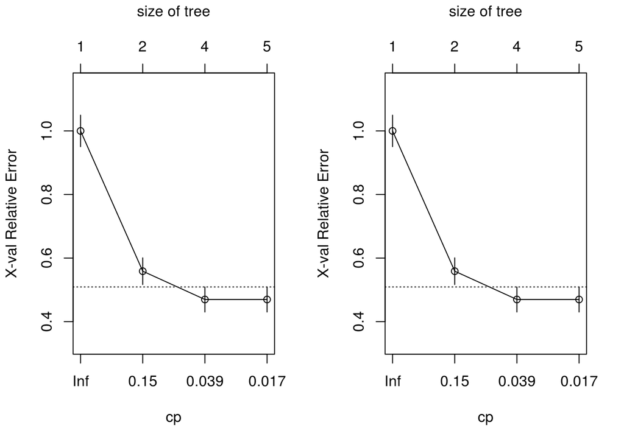

```r
# Pruning on CP=0.025
fit.pruned <- prune(fit, cp=0.025)
plotcp(fit.pruned)
```

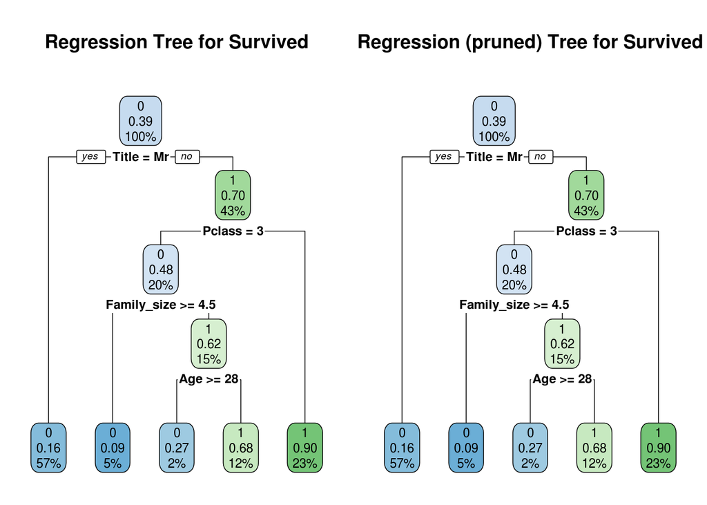

```r
rpart.plot(fit, main="Regression Tree for Survived")
rpart.plot(fit.pruned, main="Regression (pruned) Tree for Survived")
```

```r
fit.pruned$variable.importance
```

```
##       Title         Sex Family_size        Fare         Age       Parch
##   94.712557   77.284235   44.068583   40.234871   36.679929   34.055988
##      Pclass       SibSp    Embarked
##   22.977562    9.662963    4.670236
```

## Apply the model to crossSamples

Apply models to the cross validation set and calculate the confusion matrix and missclassification (pruned tree model).

Evalution (confusion matrix and missclassification) of the non-pruned model:

```r
my_prediction <- predict(fit, crossSamples, type="class")
prop.table(table(crossSamples$Survived, my_prediction))
```

```
##    my_prediction
##              0          1
##   0 0.57196970 0.06818182
##   1 0.10227273 0.25757576
```

```r
# misclassification (% of improper classifications)
mean(my_prediction != crossSamples$Survived)
```

```
## [1] 0.1704545
```

Evalution (confusion matrix and missclassification) of the pruned model:

```r
my_prediction_p <- predict(fit.pruned, crossSamples, type="class")
prop.table(table(crossSamples$Survived, my_prediction_p))
```

```
##    my_prediction_p
##              0          1
##   0 0.57196970 0.06818182
##   1 0.10227273 0.25757576
```

```r
# misclassification (% of improper classifications)
mean(my_prediction_p != crossSamples$Survived)
```

```
## [1] 0.1704545
```

## Random forest

Now, we create a random forest to avoid local minimums, which probably improve the results reducing the missclassification.

```r
require(randomForest)
fit.forest <- randomForest(Survived ~ Title + Fare + Sex + Age + Pclass + Family_size + SibSp + Embarked + Parch, data = trainSamples)
imp = importance(fit.forest, type=2)
imp[order(imp, decreasing = TRUE),] # Sort fetures by importance.
```

```
##        Fare       Title         Age         Sex      Pclass Family_size
##   51.280778   49.203304   39.987366   38.133471   23.853352   14.667334
##       SibSp    Embarked       Parch
##   11.108670    9.844940    6.447226
```

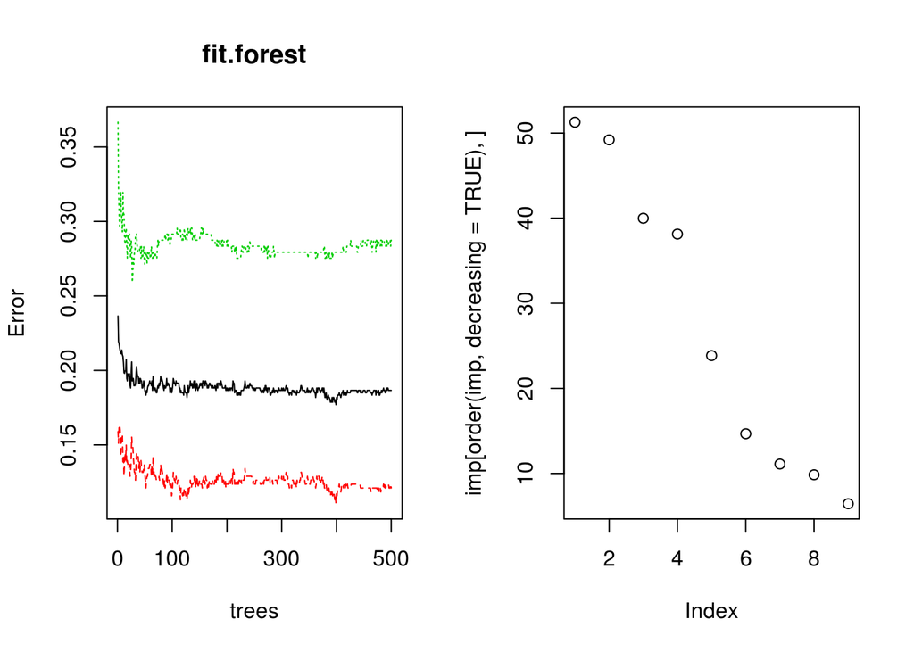

```r
par(mfrow=c(1, 2))
plot(fit.forest)
plot(imp[order(imp, decreasing = TRUE),])
```

```r
my_prediction_forest <- predict(fit.forest, crossSamples, type="class")
table(crossSamples$Survived, my_prediction_forest)
```

```
##    my_prediction_forest
##       0   1
##   0 151  18
##   1  24  71
```

```r
prop.table(table(crossSamples$Survived, my_prediction_forest))
```

```
##    my_prediction_forest
##              0          1
##   0 0.57196970 0.06818182
##   1 0.09090909 0.26893939
```

```r
mean(my_prediction_forest != crossSamples$Survived) # missclassification
```

```
## [1] 0.1590909
```

## Misclassification explanations

I think I found an algorithm (random forest) which can be applied with great results to new data sets for survival prediction purposes. Anyway, lets to examine the misclassification rates in function of the different variables used to train this model.

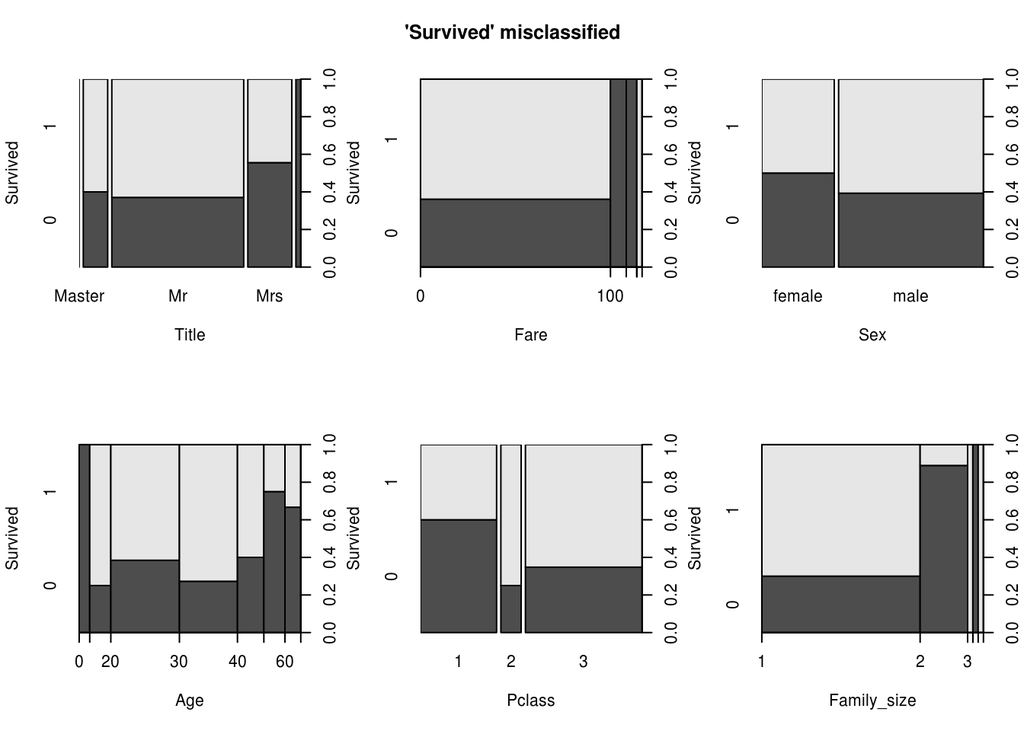

```r
misClass <- crossSamples[my_prediction_forest != crossSamples$Survived,]
welClass <- crossSamples[my_prediction_forest == crossSamples$Survived,]

# Plotting subject's variables with misclassified results.
par(mfrow=c(2, 3))
plot(Survived ~ Title + Fare + Sex + Age + Pclass + Family_size, data=misClass)
title("'Survived' misclassified", outer=TRUE, line = -2)
```

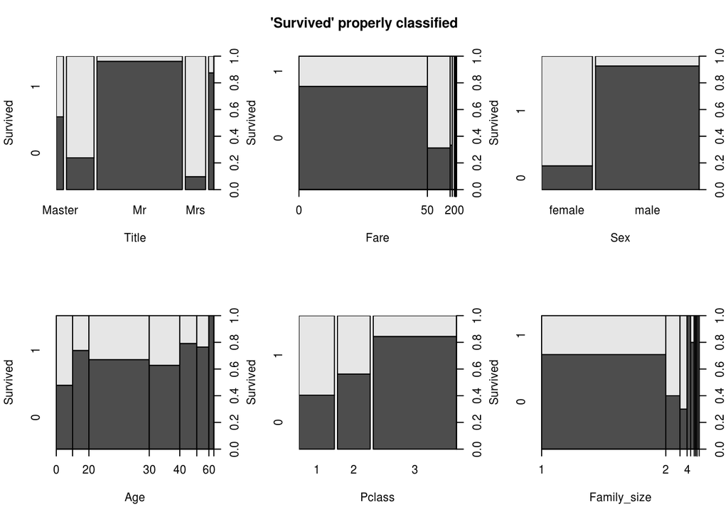

```r
# Plotting subject's variables with good classification results.
par(mfrow=c(2, 3))
plot(Survived ~ Title + Fare + Sex + Age + Pclass + Family_size, data=welClass)
title("'Survived' properly classified", outer=TRUE, line = -2)
```

Looking to the charts ‘Title’ and ‘Sex’ of both sets (bad and properly classified), different observations can be described. A different rate of survivals in (mis)classification groups can drives to think that certain variables can be treated differently, for example by value balancing or other techniques. For example, ehe subjects with values ‘Mr’ and ‘Miss’ in the ‘Title’ variable show oposite classification rates. It also happens with values ‘Female’ and ‘Male’ from the ‘Sex’ variable.